[figure not shown]

# 1 Inscripción:

- Regístrate en este link para el curso: https://forms.gle/Wh45Ys4m86tVbxco7

# 2 Fecha y Hora

- 02, 09, 16, 23 y 30 de noviembre de 2023
- 19 a 21 hs.
- Clases en vivo por ZOOM y YouTube [https://youtube.com/\@InstitutoGauss-Kish](https://youtube.com/@InstitutoGauss-Kish)

# 3 Descripción del Taller

Este curso está diseñado para personas que desean adquirir habilidades fundamentales e intermedias en el uso de Microsoft Excel. Desde la creación de hojas de cálculo básicas hasta fórmulas y funciones intermedias, te guiaremos a través de las características esenciales de Excel. Aprenderás a organizar datos, crear gráficos, utilizar funciones y más, todo para aumentar tu eficiencia en el trabajo y mejorar tus habilidades en el análisis de datos.

# 4 Por qué Deberías Participar:

- Aprenderás habilidades prácticas y aplicables en el mundo real.
- Mejorarás tu eficiencia en el trabajo y tus oportunidades laborales.
- Obtendrás un certificado de finalización al completar el curso.

# 5 Módulos:

## 5.1 Conceptos Previos

1.1. Formatos de celda

1.2. Formato Condicional

1.3. Concatenar

1.4. Dividir en Columnas

1.5. Ancho Fijo

1.6. Ancho Delimitado

1.7. Quitar Duplicados

1.8. Operaciones con distintos tipos de datos (fechas, horas, números, caracteres)

1.9. Rangos

1.10. Referencia Relativa y Referencia Absoluta.

1.11. Orden y Filtrado

## 5.2 Edición avanzada

2.1. Introducción

2.2. Operaciones con hojas

2.2.1. Selección de hojas

2.2.2. Insertar hojas de cálculo

2.2.3. Eliminar una hoja

2.2.4. Cambiar el nombre de una hoja

2.2.5. Mover y copiar hojas

2.3. Relación entre hojas y libros

2.3.1. Relación entre hojas

2.3.2. Relación entre libros

2.3.3. Vincular celdas o rangos

2.4. Bloques tridimensionales

2.4.1. Introducción de datos

2.4.2. Aplicar formato

## 5.3 Manejo de datos y gráficos

3.1. Tablas Dinámicas

3.2. Tablas auxiliares.

3.3. Presentación de Tablas Dinámicas

3.4. Análisis de la Información

3.5. Creación de gráficos dinámicos

3.6. Bases de datos

3.6.1. Actualización de la Información

3.6.2. Cambio de origen de datos

## 5.4 Funciones avanzadas

4.1. Funciones:

4.1.1. Lógicas y de comparación

4.1.1.1. Función lógica si, y , o

4.1.1.2. Contar Si

4.1.1.3. Contar Si.conjunto

4.1.1.4. Sumar Si

4.1.1.5. Sumar Si.conjunto

4.1.2. Financieras

4.1.2.1. Pago

4.1.2.2. Pagoint

4.1.2.3. Pagoprin

4.1.2.4. Pago.int.entre

4.1.2.5. Pago.princ.entre

4.1.2.6. Va

4.1.2.7. Vf

4.1.2.8. Int.acum.

4.1.3. Estadísticas

4.1.3.1. Estadística descriptiva

4.1.3.2. Estadística inferencial

4.1.4. Búsqueda y referencia

4.1.4.1. Buscar

4.1.4.2. Buscarv

4.1.4.3. Buscarh

4.2. Anidación de funciones

## 5.5 Introducción a Macros básicos

5.1. Automatización de Tareas

5.1.1. Con comandos

5.1.2. Con botones

5.1.3. Con ventanas de entradas

# 6 A quién está dirigido:

- Profesionales que deseen mejorar sus habilidades en Excel.
- Estudiantes que busquen una ventaja en sus estudios.
- Cualquier persona interesada en el uso de Excel en su trabajo o vida cotidiana.

# 7 Requisitos

No tiene requisistos previos.

# 8 Costo

- Gs. 250.000

# 9 Instructor

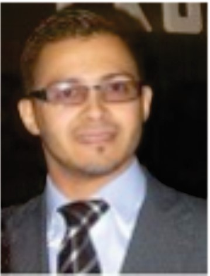

Prof. Nestor Torres

- Máster en Diseño, Evaluación y Gestión de Proyectos de Inversión (UNA)
- Licenciado en Análisis de Sistemas de Producción (UNA)
- Especialización en Didáctica Universitaria (UNA)

# 10 Contacto:

[figure not shown]